# Análisis de datos del sexo según la actividad física y el sedentarismo

Carlos de Oro Aguado

2025-04-27

## Análisis exploratorio de las variables sociodemográficas

Realizaremos un análisis de nuestra variables sociodemográficas

|  | Sexo | Frecuencia | Porcentaje |
| --- | --- | --- | --- |
| 1 | Femenino | 82 | 64.57 |
| 2 | Masculino | 45 | 35.43 |

La muestra tiene un total de 127 estudiantes donde el 64.57% son del sexo femenino y el resto del sexo masculino.

|  | Fisioterapia | Frecuencia | Porcentaje |
| --- | --- | --- | --- |
| 1 | 1er semestre | 14 | 11.02 |
| 2 | 2do semestre | 14 | 11.02 |
| 3 | 3er semestre | 29 | 22.83 |
| 4 | 4to semestre | 18 | 14.17 |
| 5 | 5to semestre | 31 | 24.41 |
| 6 | 6to semestre | 5 | 3.94 |
| 7 | 7mo semestre | 16 | 12.6 |

En la tabla anterior podemos ver que el 24.41% de los estudiantes pertenecen al 5to semestre seguido del 3er semestre con el 22.83%, donde tenemos el 6to semestre tiene una baja participación con un 3.94%.

## Análisis exploratorio de la actividad física

|  | Pregunta | Respuesta | Frecuencia | Porcentaje |
| --- | --- | --- | --- | --- |
| 1 | Q1_af | Dias por semana ( 3 DIAS) | 75 | 59.06 |
| 2 | Q1_af | Ninguna actividad fisica intensa | 52 | 40.94 |
| 3 | Q2_af | 2 horas al día | 47 | 37.01 |
| 4 | Q2_af | No sabe/ no esta seguro | 43 | 33.86 |
| 5 | Q2_af | 35 min a 1 hora | 37 | 29.13 |
| 6 | Q3_af | 3 días | 74 | 58.27 |
| 7 | Q3_af | Ninguna actividad física moderada | 53 | 41.73 |
| 8 | Q4_af | 35 min a 1 hora | 48 | 37.8 |
| 9 | Q4_af | No sabe/ no esta seguro | 38 | 29.92 |
| 10 | Q4_af | 2 horas al día | 37 | 29.13 |

[output cut: 12 more lines]

Durante los últimos 7 días, el 59.06% de los estudiantes hace 3 días por semana actividades físicas intensas tales como levantar pesos pesados, cavar, ejercicios hacer aeróbicos o andar rápido en bicicleta, habitualmente el 37.01% hace 2 horas una actividad física intensa en uno de esos días, donde el 33.86% no sabe o no esta seguro del tiempo que dedica. Tambien, durante los últimos 7 días, el 58.27% de los estudiantes hizo actividades físicas moderadas tales como transportar pesos livianos, o andar en bicicleta a velocidad regular sin caminar donde el 37.8% dedicó de 35 min a 1 hora en total a una actividad física moderada en uno de esos días. Además, el 89.76% durante los últimos 7 días, caminó 3 días por lo menos 10 minutos seguidos; habitualmente, el 39.37% en total dedicó a caminar 45 minutos en uno de esos días y el 58.27% durante los últimos 7 días, pasó sentado 6 horas durante un día hábil.

|  | Nivel_AF | Frecuencia | Porcentaje |
| --- | --- | --- | --- |
| 1 | Bajo | 29 | 22.83 |
| 2 | Moderado | 98 | 77.17 |

Podemos ver que el 77.17% de los estudiantes tienen un nivel de actividad física moderado, y el resto es bajo.

|  | Nivel_Sedentarismo | Frecuencia | Porcentaje |
| --- | --- | --- | --- |
| 1 | Moderadamente sedentatrio | 56 | 44.09 |
| 2 | Muy activo | 40 | 31.5 |
| 3 | Muy sedentario | 31 | 24.41 |

Podemos ver que el 44.09% de los estudiantes tienen un nivelmoderadamente sedentario.

## Análisis exploratorio de la actividad física según el sexo

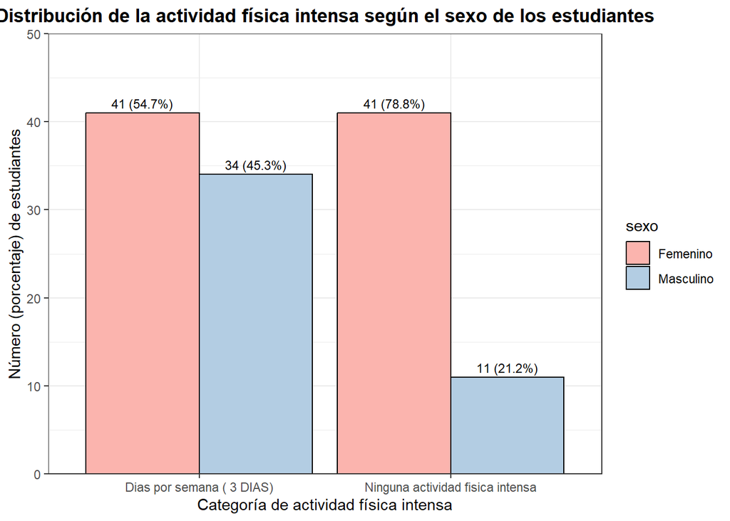

La distribución de la actividad física intensa según el sexo de los estudiantes revela diferencias notables entre mujeres y hombres. En la categoría “Días por semana (3 días)”, el 54.7% (n = 41) de los estudiantes son mujeres, mientras que el 45.3% (n = 34) son hombres. En contraste, en la categoría “Ninguna actividad física intensa”, el 78.8% (n = 41) corresponde a mujeres y solo el 21.2% (n = 11) a hombres.

```
##
##  Pearson's Chi-squared test with Yates' continuity correction
##
## data:  tabla
## X-squared = 6.8263, df = 1, p-value = 0.008983
```

La prueba Chi-cuadrado de Pearson nos indica que existe una asociación ($\chi^2=6.8263$, $p-valor < 0.01$) estadísticamente significativas entre el sexo (femenino y masculino) y la frecuencia de actividades físicas intensas realizadas durante los últimos 7 días.

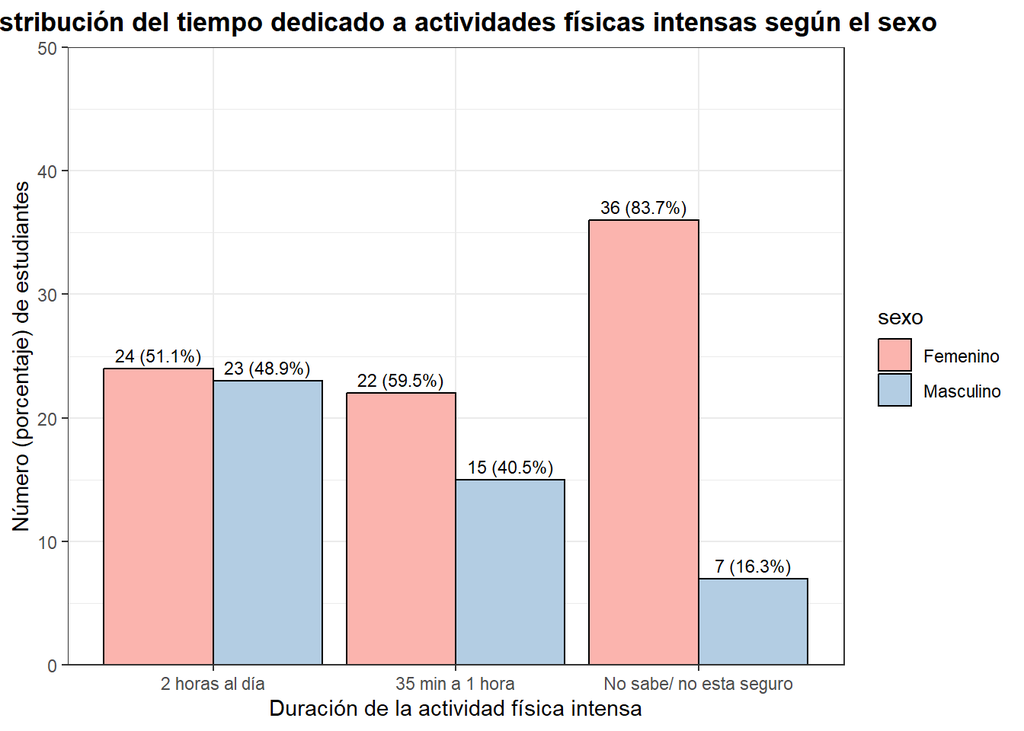

La distribución del tiempo dedicado a actividades físicas intensas según el sexo muestra diferencias relevantes entre estudiantes hombres y mujeres. En la categoría “2 horas al día”, la participación está bastante equilibrada, con un 51.1% (n = 24) de mujeres y un 48.9% (n = 23) de hombres. En la categoría “35 min a 1 hora”, las mujeres representan el 59.5% (n = 22), mientras que los hombres representan el 40.5% (n = 15), lo que refleja una mayor proporción femenina en este rango de duración.

Sin embargo, en la categoría “No sabe/No está seguro”, se observa una diferencia muy marcada: el 83.7% (n = 36) corresponde a mujeres, y solo el 16.3% (n = 7) a hombres. Esto sugiere que las mujeres presentan una mayor proporción de incertidumbre o falta de registro sobre el tiempo dedicado a este tipo de actividad.

En conjunto, estos resultados muestran que aunque en algunos rangos la distribución por sexo es relativamente balanceada, las mujeres tienden a concentrarse en los grupos con menor claridad sobre la duración de la actividad física intensa. Esto podría estar relacionado con diferencias en la percepción, el monitoreo o la autovaloración del tiempo invertido en actividad física entre ambos sexos.

```
##
##  Pearson's Chi-squared test
##
## data:  tabla
## X-squared = 11.063, df = 2, p-value = 0.00396
```

La prueba Chi-cuadrado de Pearson nos indica que existe una asociación ($\chi^2=11.063$, $p-valor < 0.01$) estadísticamente significativa entre el sexo (femenino y masculino) y la duración del tiempo dedicado a actividades físicas intensas. Esto sugiere que la distribución de los diferentes niveles de duración de las actividades físicas intensas varía significativamente entre hombres y mujeres en la muestra analizada.

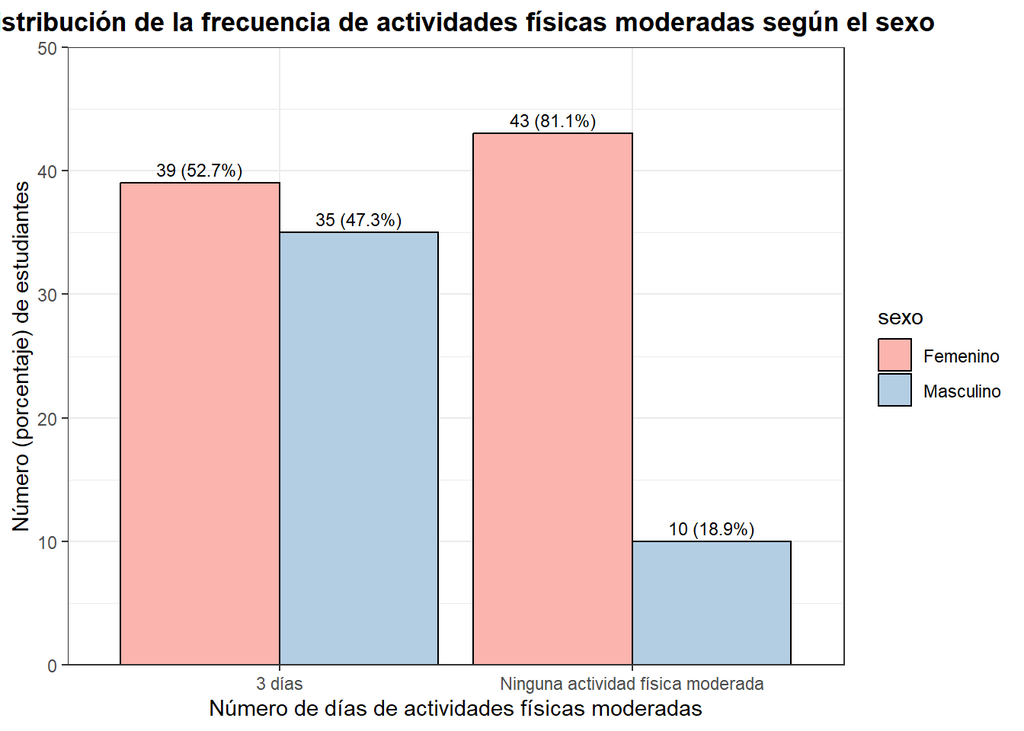

La distribución del número de días dedicados a actividades físicas moderadas según el sexo muestra diferencias notorias entre hombres y mujeres. En la categoría “3 días”, la participación es relativamente equilibrada: el 52.7% (n = 39) de los estudiantes son mujeres, mientras que el 47.3% (n = 35) son hombres.

No obstante, en la categoría “Ninguna actividad física moderada”, la diferencia es significativa. El 81.1% (n = 43) corresponde a mujeres, y solo el 18.9% (n = 10) a hombres, lo cual evidencia una brecha importante en la participación.

Estos resultados sugieren que una proporción considerablemente mayor de mujeres no realiza actividad física moderada en comparación con los hombres. Esta diferencia podría reflejar barreras, desinterés o limitaciones particulares que afectan más a las mujeres dentro del contexto analizado.

```
##
##  Pearson's Chi-squared test with Yates' continuity correction
##
## data:  tabla
## X-squared = 9.7026, df = 1, p-value = 0.00184
```

La prueba Chi-cuadrado de Pearson nos indica que existe una asociación ($\chi^2=9.7026$, $p-valor < 0.01$) estadísticamente significativa entre el sexo (femenino y masculino) y el número de días dedicados a actividades físicas moderadas. Esto sugiere que la distribución de los diferentes niveles de frecuencia de actividades físicas moderadas varía significativamente entre hombres y mujeres en la muestra analizada.

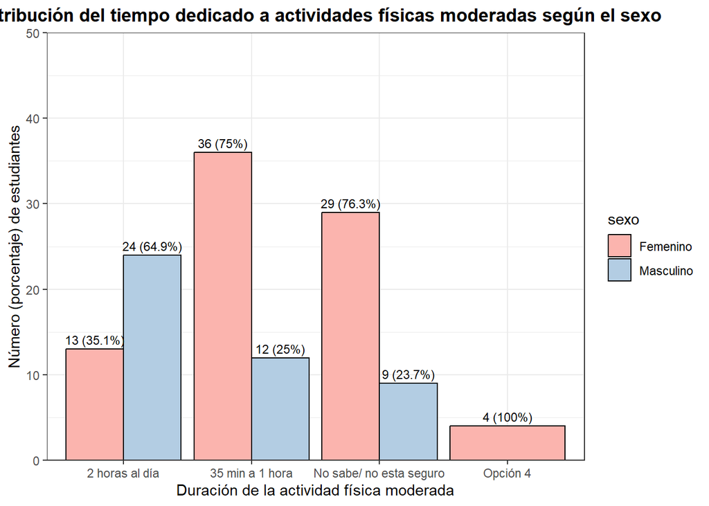

La distribución del tiempo dedicado a actividades físicas moderadas según el sexo evidencia diferencias importantes entre hombres y mujeres. En la categoría “2 horas al día”, el 64.9% (n = 24) corresponde a hombres, mientras que el 35.1% (n = 13) son mujeres, indicando una mayor dedicación masculina a este rango de tiempo.

En contraste, en la categoría “35 min a 1 hora”, las mujeres representan el 75% (n = 36), frente a un 25% (n = 12) de hombres, reflejando una clara predominancia femenina en esta duración intermedia.

En la categoría “No sabe / no está seguro”, las mujeres también predominan, con un 76.3% (n = 29), frente a un 23.7% (n = 9) de hombres. Por último, en la categoría “Opción 4”, únicamente mujeres marcaron esta opción (100%, n = 4).

Estos resultados sugieren que los hombres tienden a participar más en sesiones más largas de actividad física moderada (2 horas al día), mientras que las mujeres predominan tanto en duraciones intermedias como en los casos de incertidumbre o falta de seguimiento del tiempo. Estas diferencias podrían estar vinculadas a percepciones, hábitos o prácticas de registro diferenciadas entre ambos grupos.

```
##
##  Pearson's Chi-squared test with simulated p-value (based on 5000
##  replicates)
##
## data:  tabla
## X-squared = 20.781, df = NA, p-value = 0.0003999
```

La prueba Chi-cuadrado de Pearson, con un p-valor simulado basado en 5000 réplicas, nos indica que existe una asociación ($\chi^2=20.781$, $p-valor < 0.001$) estadísticamente significativa entre el sexo (femenino y masculino) y la duración del tiempo dedicado a actividades físicas moderadas. Esto sugiere que la distribución de los diferentes niveles de duración de las actividades físicas moderadas varía significativamente entre hombres y mujeres en la muestra analizada.

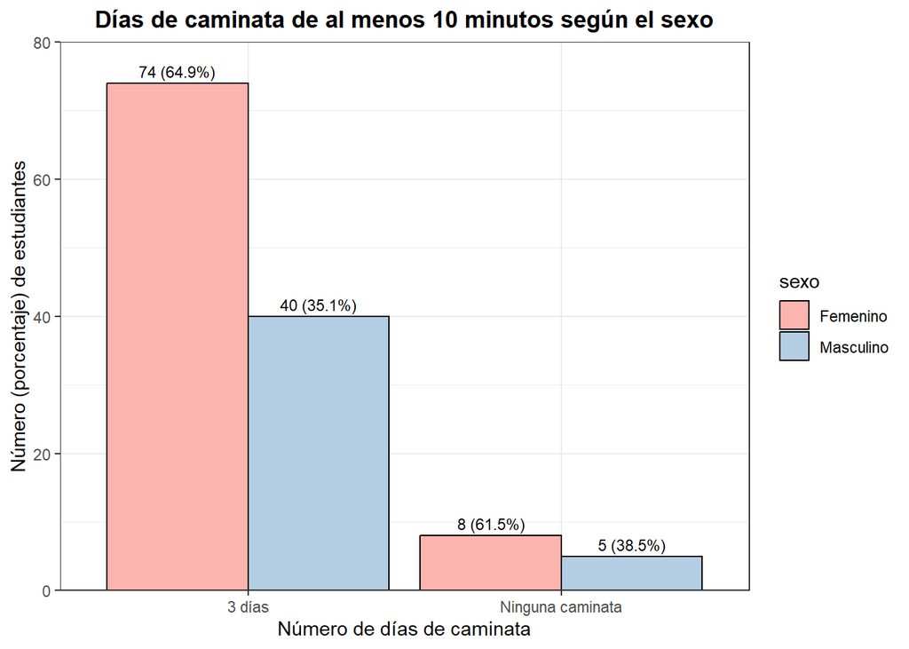

La distribución del número de días en que los estudiantes caminaron al menos 10 minutos, según el sexo, evidencia diferencias claras entre hombres y mujeres. En la categoría “3 días”, el 64.9% (n = 74) corresponde a mujeres, mientras que el 35.1% (n = 40) son hombres, lo que indica una mayor frecuencia de caminata reportada por las mujeres.

En la categoría “Ninguna caminata”, también predominan las mujeres, con un 61.5% (n = 8), frente al 38.5% (n = 5) de hombres.

```
##
##  Pearson's Chi-squared test with simulated p-value (based on 5000
##  replicates)
##
## data:  tabla
## X-squared = 0.058059, df = NA, p-value = 1
```

La prueba Chi-cuadrado de Pearson, con un p-valor simulado basado en 5000 réplicas, nos indica que no existe una asociación ($\chi^2=0.0581$, p-valor=1) estadísticamente significativa entre el sexo (femenino y masculino) y el número de días que los estudiantes caminaron al menos 10 minutos. Esto sugiere que la distribución de los diferentes niveles de caminata no varía significativamente entre hombres y mujeres en la muestra analizada.

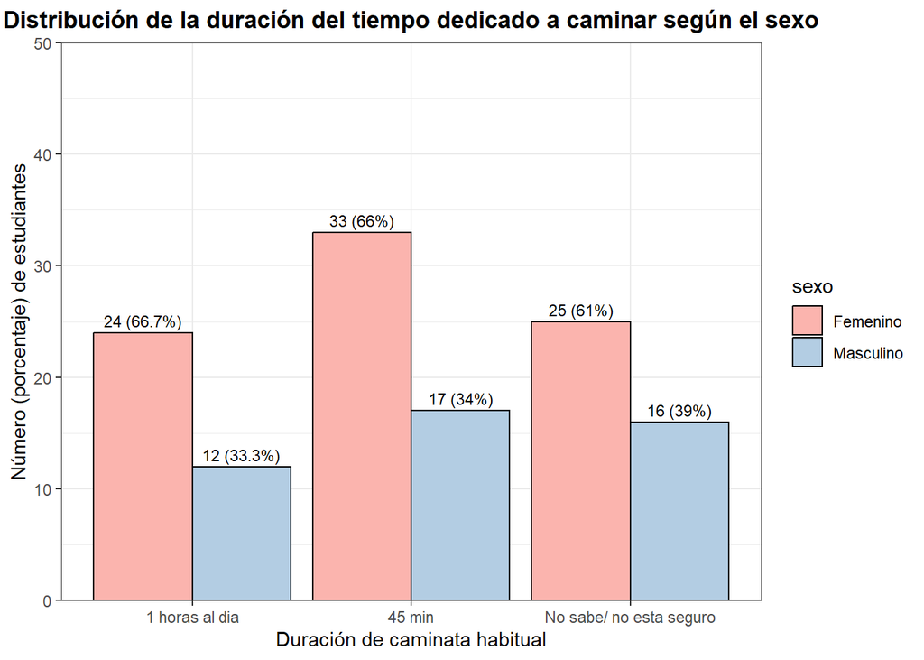

La distribución de la duración del tiempo dedicado a caminar según el sexo evidencia diferencias claras entre hombres y mujeres. En la categoría “1 hora al día”, el 66.7% (n = 24) corresponde a mujeres, mientras que el 33.3% (n = 12) son hombres.

En la categoría “45 minutos”, las mujeres también predominan, representando el 66% (n = 33), frente al 34% (n = 17) de hombres. Finalmente, en la categoría “No sabe / no está seguro”, el 61% (n = 25) corresponde a mujeres, y el 39% (n = 16) a hombres.

```
##
##  Pearson's Chi-squared test
##
## data:  tabla
## X-squared = 0.3454, df = 2, p-value = 0.8414
```

La prueba Chi-cuadrado de Pearson nos indica que no existe una asociación ($\chi^2=0.3454$, $p-valor=0.8414$) estadísticamente significativa entre el sexo (femenino y masculino) y la duración del tiempo dedicado a caminar. Esto sugiere que la distribución de los diferentes niveles de duración de caminata no varía significativamente entre hombres y mujeres en la muestra analizada.

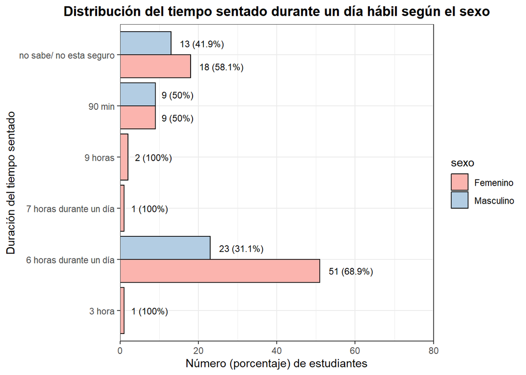

La distribución del tiempo sentado durante un día hábil según el sexo evidencia una clara concentración en la categoría “6 horas durante un día”, donde las mujeres representan el 68.9% (n = 51) y los hombres el 31.1% (n = 23), lo cual indica que esta duración es común en ambos sexos, pero con predominancia femenina.

En otras categorías específicas, como “90 minutos”, se observa una distribución equitativa entre mujeres y hombres, cada uno con el 50% (n = 9). En la categoría “no sabe / no está seguro”, el 58.1% (n = 18) corresponde a mujeres y el 41.9% (n = 13) a hombres, lo cual sugiere una leve mayor proporción femenina en la falta de certeza sobre su tiempo sentado.

Llama la atención que las categorías de “3 horas”, “7 horas” y “9 horas” fueron reportadas exclusivamente por mujeres, aunque en números absolutos bajos (n = 1–2), lo cual puede deberse a casos puntuales o sesgos de autorregistro.

En conjunto, estos resultados sugieren que, aunque existe una tendencia general de ambos sexos a permanecer sentados durante largos periodos, las mujeres presentan una mayor proporción en los niveles más altos de sedentarismo (6 horas o más), así como en la categoría de no tener claridad sobre el tiempo exacto. Esto podría reflejar diferencias en rutinas diarias, distribución de tareas o percepción del tiempo sedentario entre los sexos en la muestra evaluada.

```
##
##  Pearson's Chi-squared test with simulated p-value (based on 5000
##  replicates)
##
## data:  tabla
## X-squared = 5.0502, df = NA, p-value = 0.4143
```

La prueba Chi-cuadrado de Pearson, con un p-valor simulado basado en 5000 réplicas, nos indica que no existe una asociación($\chi^2=5.0502$, p-valor=0.4143171) estadísticamente significativa entre el sexo (femenino y masculino) y la duración del tiempo que los estudiantes pasaron sentados durante un día hábil. Esto sugiere que la distribución de los diferentes niveles de tiempo sentado no varía significativamente entre hombres y mujeres en la muestra analizada.

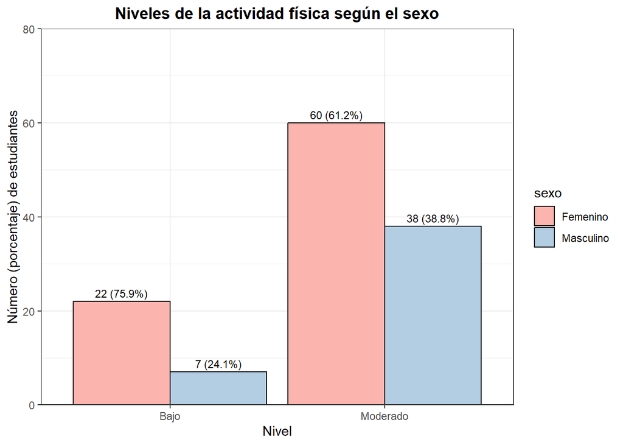

La distribución del nivel de actividad física según el sexo muestra una clara predominancia femenina en ambos niveles reportados, especialmente en los niveles más bajos. En la categoría “Bajo”, el 75.9% (n = 22) de los estudiantes son mujeres, mientras que solo el 24.1% (n = 7) son hombres, lo que indica una diferencia notable en la prevalencia de inactividad o actividad reducida entre los sexos.

En la categoría “Moderado”, aunque la participación de ambos sexos es más equilibrada, las mujeres siguen siendo mayoría con un 61.2% (n = 60), frente al 38.8% (n = 38) de hombres.

Estos resultados sugieren que las mujeres tienden a presentar niveles más bajos de actividad física en comparación con los hombres dentro de la muestra analizada. Esta tendencia podría reflejar diferencias en las rutinas, percepciones, motivaciones o barreras estructurales que afectan la práctica de actividad física entre los sexos.

```
##
##  Pearson's Chi-squared test with Yates' continuity correction
##
## data:  tabla
## X-squared = 1.5048, df = 1, p-value = 0.2199
```

La prueba Chi-cuadrado de Pearson nos indica que no existe una asociación ($\chi^2=1.5048$, $p-valor=0.2199$) estadísticamente significativa entre el sexo (femenino y masculino) y el nivel de la actividad física. Esto sugiere que la distribución de los diferentes niveles de actividad físitca no varía significativamente entre hombres y mujeres en la muestra analizada.

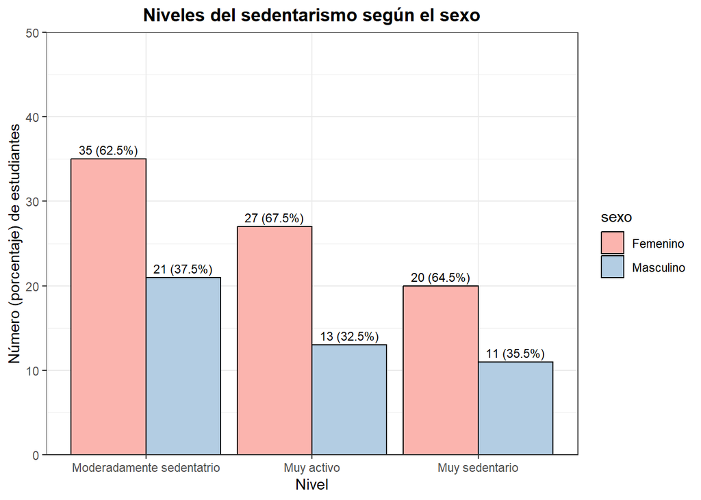

La distribución de los niveles de sedentarismo según el sexo muestra una clara tendencia a mayor prevalencia femenina en todas las categorías. En el nivel “Moderadamente sedentario”, las mujeres representan el 62.5% (n = 35), mientras que los hombres corresponden al 37.5% (n = 21).

En el nivel “Muy sedentario”, esta diferencia también es evidente: 64.5% (n = 20) de los estudiantes son mujeres frente a un 35.5% (n = 11) de hombres.

Incluso en la categoría “Muy activo”, que representa a los estudiantes con menor nivel de sedentarismo, las mujeres siguen predominando con un 67.5% (n = 27), frente a un 32.5% (n = 13) de hombres.

```
##
##  Pearson's Chi-squared test
##
## data:  tabla
## X-squared = 0.25502, df = 2, p-value = 0.8803
```

La prueba Chi-cuadrado de Pearson nos indica que no existe una asociación ($\chi^2=0.2550$, $p-valor=0.8803$) estadísticamente significativa entre el sexo (femenino y masculino) y el nivel de sedentarismo. Esto sugiere que la distribución de los diferentes niveles de sedentarismo no varía significativamente entre hombres y mujeres en la muestra analizada.

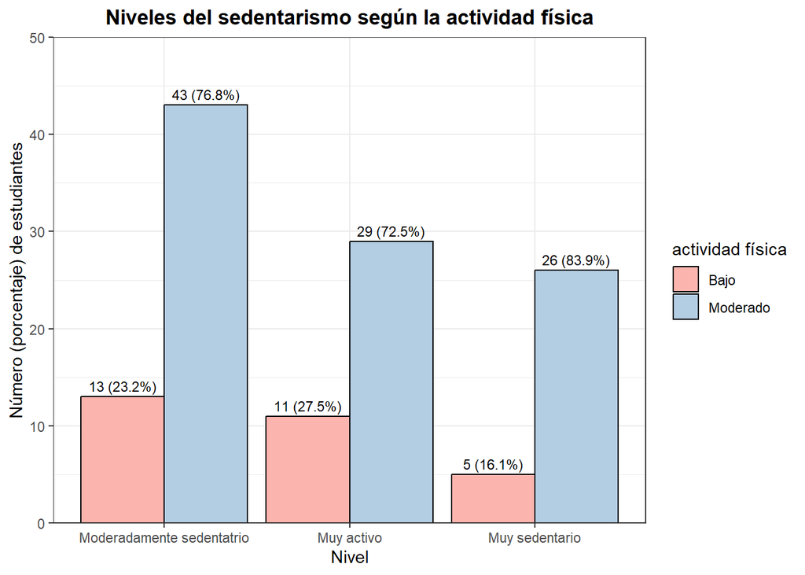

En el grupo “Moderadamente sedentario”, el 76.8% (n = 43) de los estudiantes pertenecen al grupo de actividad física moderada, frente a un 23.2% (n = 13) con nivel bajo de actividad física. Esta proporción se mantiene similar en la categoría “Muy activo”, donde el 72.5% (n = 29) pertenece al grupo moderado y el 27.5% (n = 11) al grupo de baja actividad física.

La diferencia se acentúa en la categoría “Muy sedentario”, donde el 83.9% (n = 26) corresponde al grupo con actividad física moderada, mientras que solo el 16.1% (n = 5) pertenece al grupo con baja actividad física.

Estos resultados sugieren una aparente paradoja: a pesar de tener niveles moderados de actividad física, los estudiantes pueden acumular altos niveles de sedentarismo. Esto podría deberse a que la actividad física se concentra en periodos específicos del día, mientras el resto del tiempo se dedica a actividades sedentarias como estudio, trabajo en computadora o clases virtuales. La coexistencia de actividad física estructurada y sedentarismo prolongado resalta la importancia de analizar ambos comportamientos por separado en el contexto de salud pública y hábitos de vida activa.

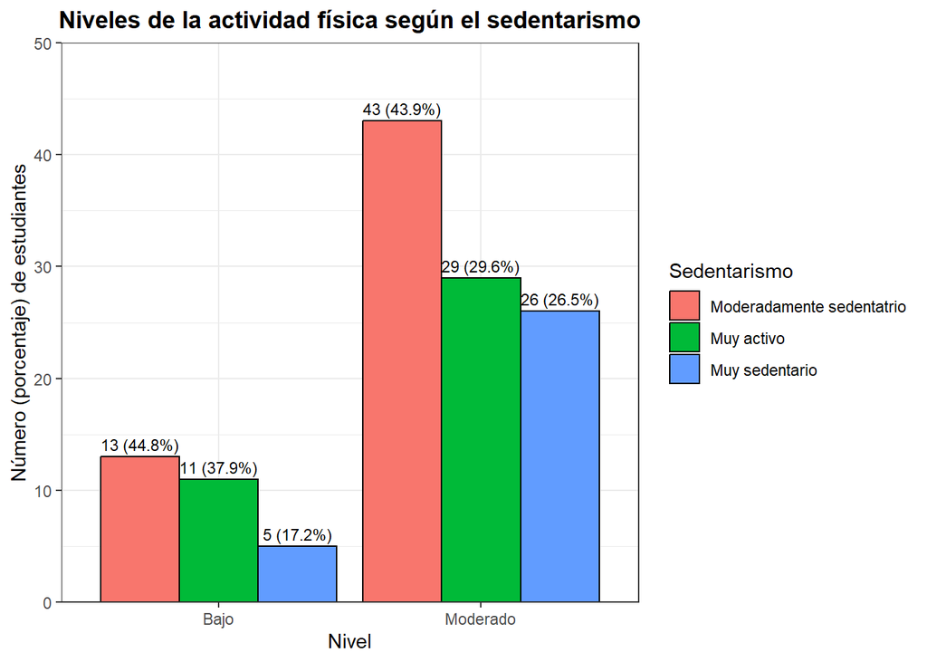

La distribución de los niveles de actividad física en función del sedentarismo revela diferencias interesantes en los patrones de comportamiento físico entre los estudiantes.

En la categoría de actividad física baja, se observa que la mayor proporción pertenece al grupo moderadamente sedentario con un 44.8% (n = 13), seguido por el grupo muy activo con 37.9% (n = 11), y finalmente el grupo muy sedentario con solo 17.2% (n = 5). Esta distribución sugiere que incluso los estudiantes clasificados como muy activos pueden reportar bajos niveles de actividad física, posiblemente debido a diferencias en la frecuencia, intensidad o tipo de actividad reportada.

En la categoría de actividad física moderada, el grupo moderadamente sedentario nuevamente lidera con un 43.9% (n = 43), pero le siguen de cerca los grupos muy activo (29.6%, n = 29) y muy sedentario (26.5%, n = 26), lo que indica una coexistencia de sedentarismo y actividad física moderada en diferentes perfiles estudiantiles.

Estos resultados refuerzan la idea de que los niveles de actividad física y de sedentarismo no son necesariamente excluyentes. Es posible que estudiantes con una rutina de ejercicios moderada también pasen muchas horas al día en actividades sedentarias como el estudio o el trabajo en computador. Por tanto, es fundamental analizar ambas dimensiones de forma independiente y complementaria para comprender integralmente los hábitos de movimiento y reposo en la población evaluada.

```
##
##  Pearson's Chi-squared test
##
## data:  tabla
## X-squared = 1.2898, df = 2, p-value = 0.5247
```

La prueba Chi-cuadrado de Pearson nos indica que no existe una asociación ($\chi^2=1.2898$, $p-valor=0.5247$) estadísticamente significativa entre los niveles de la actividad física y el nivel de sedentarismo. Esto sugiere que la distribución de los diferentes niveles de sedentarismo no varía significativamente entre los niveles de la actividad física en la muestra analizada.

|  | Bajo | Moderado |
| --- | --- | --- |
| Femenino | 22 | 60 |
| Masculino | 7 | 38 |

```
##              Outcome +    Outcome -      Total                 Inc risk *
## Exposed +           22           60         82     26.83 (17.64 to 37.76)
## Exposed -            7           38         45      15.56 (6.49 to 29.46)
## Total               29           98        127     22.83 (15.86 to 31.12)
##
## Point estimates and 95% CIs:
## -------------------------------------------------------------------
## Inc risk ratio                                 1.72 (0.80, 3.72)
## Inc odds ratio                                 1.99 (0.78, 5.11)
## Attrib risk in the exposed *                   11.27 (-3.01, 25.56)
## Attrib fraction in the exposed (%)            42.02 (-25.08, 73.12)
## Attrib risk in the population *                7.28 (-5.58, 20.14)
## Attrib fraction in the population (%)         31.88 (-22.25, 62.04)
## -------------------------------------------------------------------
## Uncorrected chi2 test that OR = 1: chi2(1) = 2.096 Pr>chi2 = 0.148
## Fisher exact test that OR = 1: Pr>chi2 = 0.187
##  Wald confidence limits
##  CI: confidence interval
##  * Outcomes per 100 population units
```

## Análisis de asociación entre Nivel de Actividad Física y Sexo

Se evaluó si existe una asociación entre el sexo (femenino vs masculino) y el nivel de actividad física bajo en una muestra de estudiantes. A continuación se presentan los resultados obtenidos con base en una tabla 2x2 y los respectivos indicadores epidemiológicos.

### Riesgo en expuestos (mujeres)

El **26.8%** de las mujeres presentan un nivel bajo de actividad física. **IC95%:** 17.64% – 37.76%

### Riesgo en no expuestos (hombres)

El **15.6%** de los hombres presentan un nivel bajo de actividad física. **IC95%:** 6.49% – 29.46%

## Medidas de Asociación

### Razón de Riesgos (Risk Ratio): **1.72** (IC95%: 0.80 – 3.72)

La probabilidad de tener un nivel bajo de actividad física es **1.72 veces mayor en mujeres** que en hombres. Esta asociación **no es estadísticamente significativa**, ya que el intervalo de confianza incluye el valor 1.

### Razón de Momios (Odds Ratio): **1.99** (IC95%: 0.78 – 5.11)

“La razón entre presentar un nivel bajo de actividad física versus uno moderado es **1.99 veces mayor en las mujeres** en comparación con los hombres. Esta asociación **no es estadísticamente significativa**”.

## Medidas de Impacto

### Fracción atribuible en expuestas: **42.02%** (IC95%: -25.08% – 73.12%)

El **42%** de los casos de bajo nivel de actividad física en mujeres podrían estar relacionados con su condición de exposición. Esta fracción **no es estadísticamente significativa**.

### Riesgo atribuible en la población: **7.28** (IC95%: -5.58 – 20.14)

En la población total, se estima que el **7.3%** del bajo nivel de actividad física podría ser atribuible al sexo femenino. Esta medida **no es estadísticamente significativa**.

### Fracción atribuible en la población: **31.88%** (IC95%: -22.25% – 62.04%)

Aproximadamente el **32%** de los casos en la población total podrían estar relacionados con el sexo femenino.Este valor **no es significativo**.

## Pruebas estadísticas

- **Chi_cuadrado = 2.096**
- **p-valor = 0.148**
- **Fisher exact test p-valor = 0.187**

Ambas pruebas confirman que **no existe una asociación estadísticamente significativa** entre el sexo y el nivel bajo de actividad física en esta muestra.

## Conclusión

Aunque se observa una mayor proporción de bajo nivel de actividad física entre las mujeres en comparación con los hombres, **las medidas de asociación y pruebas estadísticas no son significativas**. Esto sugiere que las diferencias observadas podrían deberse al azar y no a una relación causal real.

|  | Bajo | Moderado |
| --- | --- | --- |
| Femenino | 22 | 60 |
| Masculino | 7 | 38 |

```
## Call:
## multinom(formula = Nivel_Sedentarismo ~ Sexo, data = df)
##
## Coefficients:
##                          (Intercept) SexoMasculino
## Moderadamente sedentario   0.2594049     0.2200814
## Muy sedentario            -0.3001468     0.1332633
##
## Std. Errors:
##                          (Intercept) SexoMasculino
## Moderadamente sedentario   0.2561403     0.4360668
## Muy sedentario             0.2950158     0.5048279
##
## Residual Deviance: 271.3104
## AIC: 279.3104
```

```
##                          (Intercept) SexoMasculino
## Moderadamente sedentario   0.3111818     0.6137720
## Muy sedentario             0.3089669     0.7917971
```

[output not shown]

## Análisis de asociación entre Nivel de Sedentarismo y Sexo

Se evaluó la asociación entre el sexo (femenino vs masculino) y el nivel de sedentarismo en una muestra de estudiantes, mediante un modelo de regresión logística multinomial. La categoría de referencia utilizada fue **“Muy activo”**. A continuación, se presentan las medidas de asociación estimadas y su interpretación.